# Segmentação/Classificação no R

Felipe Barros

5 de junho de 2016

Há algum tempo comecei a usar mais o software *R* para análises espaciais. Trata-se de um software de grande possibilidade para análise exploratória e modelagens estatísticas. O que eu não imaginei foi a possibilidade de utilizá-lo para sensoriamento remoto.

E o mais louco de tudo isso é a possibilidade de faze tais análises (por exemplo, classificação de imagem de satélite) sem a necessidade de pacotes específicos. Afinal, em sua maioria, estamos sempre trabalhando com estatística, independente da finalidade.

Resolvi, portanto, compartilhar aqui uma classificação não supervisionada que fiz baseada no algoritmos K-means. De início estava interessado em entender o processo de segmentação, como o de crescimento de região, disponível no software *SPRING*. Há diferentes algoritmos de segmentação de imagens e a ideia geral é agrupar pixels com características similares, como por exemplo, nível de cinza, textura e contraste, resultando em áreas com resposta espectral homogêneas (ou melhor, dentor de um padrão). Não sou especialista, por isso incentivo à todos que pesquisem mais a respeito [no manual *spring*](http://www.mundogeomatica.com.br/Livros/Livro_Spring_5.1.2_Aplicacoes_Praticas/LivroSPRING512PassoaPassoAplicacaoPratica.pdf) ou no [artigo do Sadeck](https://geotecnologias.wordpress.com/2010/08/19/classificacao-orientada-a-objeto-consideracoes/).

## K-means

O algoritmo K-means, foi colocado no [artigo do Sadeck](https://geotecnologias.wordpress.com/2010/08/19/classificacao-orientada-a-objeto-consideracoes/) como um possível algoritmo de segmentação. Contudo, por ele realizar uma análise de agrupamento (*clustering*), e definir classes de grupos a cada pixel, estarei o considerando aqui, como um algoritmo de classificação **não supervisionado**. Logo, o algoritmo K-means **não está baseada no método de crescimento por região**, que era meu objetivo inicial.

Oque faz o K-means? O algoritmo cria $k$ grupos com respostas espectrais similares a partir dos valores dos pixels da(s) imagem(ns). Portanto, não consideram elementos como, contraste e textura. Esta abordagem classifica da imagem em $k$ grupos (definidos à priori pelo usário), que serão agrupados (classificados) estatísticamente em diferentes iterações de forma a reduzir o erro qudrático médio intra grupos e, por consequência, aumentar a distância entre os grupos (*clusters*). Para mais informações [Kmeans](https://en.wikipedia.org/wiki/K-means_clustering).

## Classificação não supervisionada no R

### Dados básicos da análise

Para a classificação vou usar a cena com todas as bandas mais o NDVI. Na figura abaixo, vemos a composição r=4, g=2 e b=1.

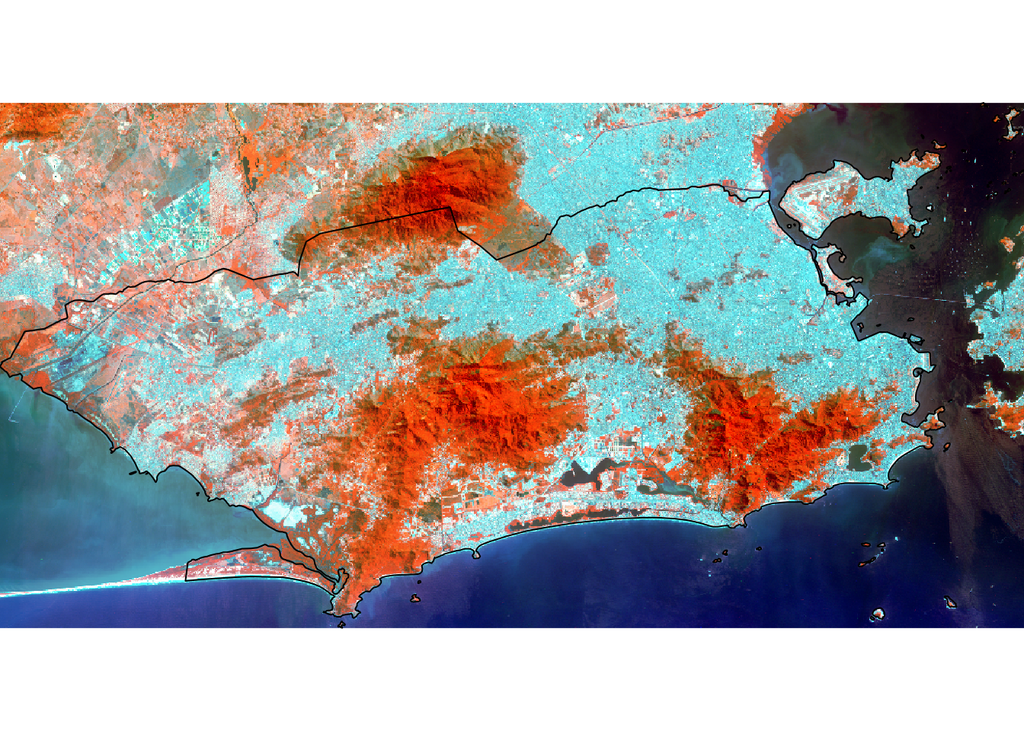

Analisando o histograma das bandas 1, 2, 3 e 4 (para simplificar a visualização).

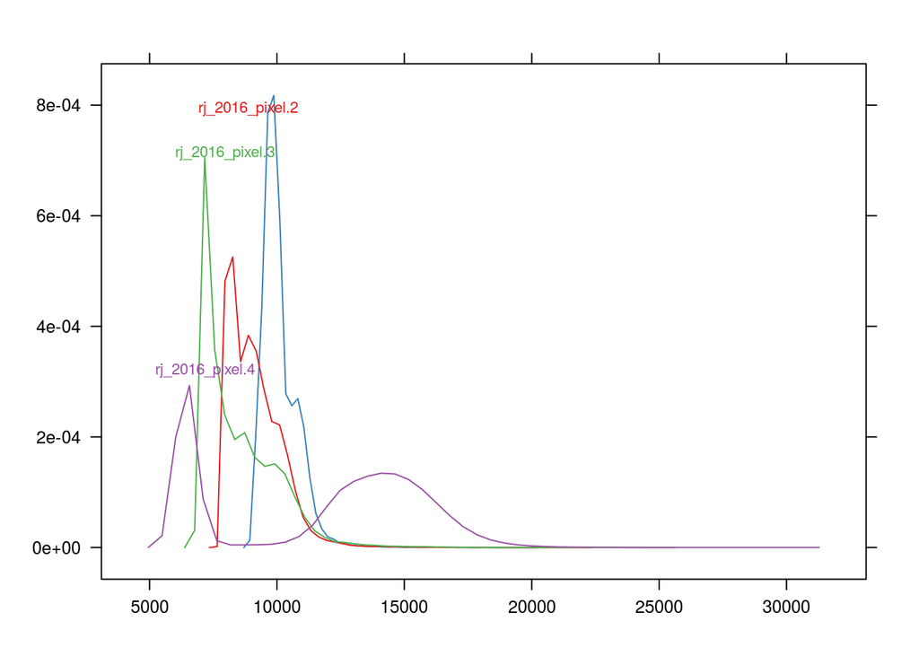

## Resultado

Da cena utilizada, fizemos a classificação em seis grupos distintos, ilustrados abaixo.

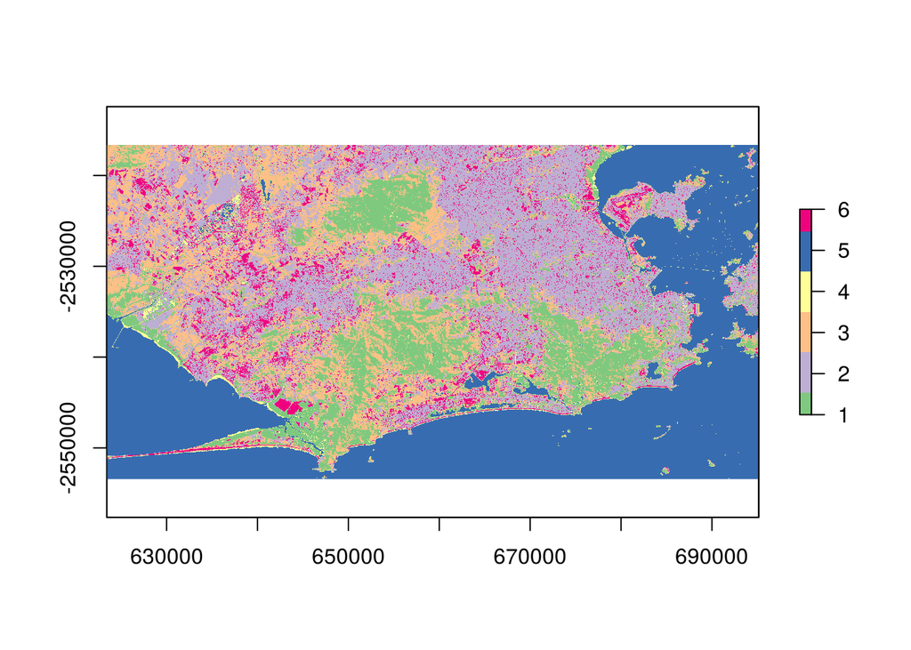

O tempo de processamento é curtíssimo. **Sim, eu sei. Esse processo não é nenhuma novidade. Contudo, acredito ser de grande valia por termos a possibilidade de nos apropiarmos dos resultados estatísticos para explora-los, tanto no pré quanto no pós processamento.**

Visualmente, poderíamos atribuir aos grupos as seguintes classes:

1. **classe 1**, com cor **verde**: poderia ser classificada como **áreas florestais**
2. **classe 2**, com cor **roxa** (ou coisa parecida): seriam as **áreas urbanas**
3. **classe 3**, com cor **laranja**: seriam áreas florestais, mas com alguma diferença da **classe 1** (possivelmente em diferente estágio sucessional ou nível de degradação)
4. **classe 4**, em **amarelo**: que pouco aparecem, seriam **áreas de areia**
5. **classe 5**, em **azul**: seriam **corpos d’água**
6. **classe 6**, em **vermelho**: **áreas urbanas**, mas com resposta diferente da **classe 2**

## Perspectivas futuras

Ainda não pude pesquisar, mas imagino que existam pacotes específicos do **R** para Sensoriamento Remoto, que poderão nos ajudar bastante em análises complementares.

Comentários são bem-vindos e caso também estejamexplorando o universo **R** e tenham curiosidade, avisem que compartilho o script!

Até a próxima.